# ОИ2:эксплораторный анализ

Багрова Ольга

2022-10-10

```r
library(tidyverse)
library(gtsummary)
library(factoextra)
library(ggbiplot)
library(ggplot2)
library(ggpubr)
library(dplyr)
library(plotly)
library(tibble)
library(matrixStats)
```

#Анализ клинических данных

##Пациенты

Из файла: data_clinical_patient.txt

```r
patients <- read_tsv("data_clinical_patient.txt", skip = 4)
skimr::skim(patients)
```

Data summary

| Name | patients |
| --- | --- |
| Number of rows | 442 |
| Number of columns | 37 |
| _______________________ |  |
| Column type frequency: |  |
| character | 28 |
| logical | 3 |
| numeric | 6 |
| ________________________ |  |
| Group variables | None |

**Variable type: character**

| skim_variable | n_missing | complete_rate | min | max | empty | n_unique | whitespace |
| --- | --- | --- | --- | --- | --- | --- | --- |
| PATIENT_ID | 0 | 1.00 | 12 | 12 | 0 | 442 | 0 |
| SUBTYPE | 79 | 0.82 | 4 | 4 | 0 | 1 | 0 |
| CANCER_TYPE_ACRONYM | 0 | 1.00 | 4 | 4 | 0 | 1 | 0 |
| OTHER_PATIENT_ID | 0 | 1.00 | 36 | 36 | 0 | 442 | 0 |
| SEX | 0 | 1.00 | 4 | 6 | 0 | 2 | 0 |
| AJCC_PATHOLOGIC_TUMOR_STAGE | 37 | 0.92 | 7 | 16 | 0 | 14 | 0 |
| AJCC_STAGING_EDITION | 15 | 0.97 | 3 | 3 | 0 | 7 | 0 |
| DAYS_LAST_FOLLOWUP | 155 | 0.65 | 1 | 11 | 0 | 271 | 0 |
| DAYS_TO_BIRTH | 0 | 1.00 | 5 | 11 | 0 | 430 | 0 |
| ETHNICITY | 12 | 0.97 | 18 | 22 | 0 | 2 | 0 |
| FORM_COMPLETION_DATE | 0 | 1.00 | 6 | 8 | 0 | 113 | 0 |
| HISTORY_NEOADJUVANT_TRTYN | 0 | 1.00 | 2 | 3 | 0 | 2 | 0 |
| ICD_10 | 0 | 1.00 | 3 | 6 | 0 | 45 | 0 |
| ICD_O_3_HISTOLOGY | 0 | 1.00 | 6 | 6 | 0 | 9 | 0 |
| ICD_O_3_SITE | 0 | 1.00 | 5 | 5 | 0 | 44 | 0 |
| INFORMED_CONSENT_VERIFIED | 0 | 1.00 | 3 | 3 | 0 | 1 | 0 |
| NEW_TUMOR_EVENT_AFTER_INITIAL_TREATMENT | 13 | 0.97 | 2 | 3 | 0 | 2 | 0 |
| PATH_M_STAGE | 28 | 0.94 | 2 | 3 | 0 | 5 | 0 |
| PATH_N_STAGE | 21 | 0.95 | 2 | 3 | 0 | 10 | 0 |
| PATH_T_STAGE | 29 | 0.93 | 2 | 3 | 0 | 15 | 0 |
| PERSON_NEOPLASM_CANCER_STATUS | 26 | 0.94 | 10 | 10 | 0 | 2 | 0 |
| PRIOR_DX | 0 | 1.00 | 2 | 3 | 0 | 2 | 0 |
| RACE | 8 | 0.98 | 5 | 25 | 0 | 3 | 0 |
| RADIATION_THERAPY | 7 | 0.98 | 2 | 3 | 0 | 2 | 0 |
| IN_PANCANPATHWAYS_FREEZE | 0 | 1.00 | 2 | 3 | 0 | 2 | 0 |
| OS_STATUS | 7 | 0.98 | 8 | 10 | 0 | 2 | 0 |
| DSS_STATUS | 13 | 0.97 | 17 | 26 | 0 | 2 | 0 |
| PFS_STATUS | 7 | 0.98 | 10 | 13 | 0 | 2 | 0 |

**Variable type: logical**

| skim_variable | n_missing | complete_rate | mean | count |
| --- | --- | --- | --- | --- |
| PRIMARY_LYMPH_NODE_PRESENTATION_ASSESSMENT | 442 | 0 | NaN | : |
| DFS_STATUS | 442 | 0 | NaN | : |
| DFS_MONTHS | 442 | 0 | NaN | : |

**Variable type: numeric**

| skim_variable | n_missing | complete_rate | mean | sd | p0 | p25 | p50 | p75 | p100 | hist |
| --- | --- | --- | --- | --- | --- | --- | --- | --- | --- | --- |
| AGE | 8 | 0.98 | 57.52 | 15.71 | 15 | 47.00 | 58.00 | 70.00 | 90.00 | ▂▃▇▇▃ |
| DAYS_TO_INITIAL_PATHOLOGIC_DIAGNOSIS | 8 | 0.98 | 0.00 | 0.00 | 0 | 0.00 | 0.00 | 0.00 | 0.00 | ▁▁▇▁▁ |
| WEIGHT | 208 | 0.53 | 82.02 | 19.24 | 40 | 70.00 | 81.00 | 90.00 | 161.00 | ▃▇▃▁▁ |
| OS_MONTHS | 15 | 0.97 | 62.67 | 64.18 | 0 | 18.31 | 41.56 | 80.94 | 369.92 | ▇▂▁▁▁ |
| DSS_MONTHS | 15 | 0.97 | 62.67 | 64.18 | 0 | 18.31 | 41.56 | 80.94 | 369.92 | ▇▂▁▁▁ |
| PFS_MONTHS | 14 | 0.97 | 43.37 | 54.66 | 0 | 9.57 | 24.85 | 51.88 | 368.77 | ▇▁▁▁▁ |

*Всего пациентов 442*

Описание файла:

- PATIENT_ID - идентификатор пациента (TCGA-3N-A9WC)
- SUBTYPE - название проекта (SKCM)
- CANCER_TYPE_ACRONYM - TCGA PanCanAtlas аббревиатура типа рака (SKCM)
- OTHER_PATIENT_ID - Устаревший идентификатор пациента DMP
- AGE - возраст когда болезнь впервые диагностирована
- SEX - пол
- AJCC_PATHOLOGIC_TUMOR_STAGE - Степень злокачественности по критериям AJCC (STAGE IIIA)
- AJCC_STAGING_EDITION - Издание публикации Американского объединенного комитета по борьбе с раком (7TH)
- DAYS_LAST_FOLLOWUP - Количество дней от даты последнего наблюдения до даты первоначальной постановки диагноза (387)
- DAYS_TO_BIRTH - Количество дней от дня рождения до дня первоначально поставленного диагноза (-30163)
- DAYS_TO_INITIAL_PATHOLOGIC_DIAGNOSIS - Количество дней от последнего дня когда чел был жив (известно), до даты первоначального диагноза (0)
- ETHNICITY - этническая характеристика (Not Hispanic Or Latino)
- FORM_COMPLETION_DATE - дата заполнения формы (5/29/14)
- HISTORY_NEOADJUVANT_TRTYN - неадъювантное лечение (т.е. с помощью ЛП) пациента до резекции опухоли (No)
- ICD_10 - классификация ICD-10 (C44.9) типо международная классификация болезней
- ICD_O_3_HISTOLOGY - международная классификация онко заболеваний: гистологический код (8720/3)
- ICD_O_3_SITE - международная классификация онко заболеваний: site код (C77.3)
- INFORMED_CONSENT_VERIFIED - есть ли информированное согласие (Yes)
- NEW_TUMOR_EVENT_AFTER_INITIAL_TREATMENT - была ли у пациента новая опухоль после первоначального лечения (Yes)
- PATH_M_STAGE - коды метастаз (M0)
- PATH_N_STAGE - коды неоплайзии (NX)
- PATH_T_STAGE - коды опухоли (T2A)
- PERSON_NEOPLASM_CANCER_STATUS - Статус рака новообразования человека(Tumor Free)
- PRIMARY_LYMPH_NODE_PRESENTATION_ASSESSMENT - Оценка первичного расположения лимфатических узлов ПУСТЫЕ
- PRIOR_DX - Предварительный диагноз (No)
- RACE - раса (White)
- RADIATION_THERAPY- была ли лучевая терапия (No)
- WEIGHT - вес пациента (68)
- IN_PANCANPATHWAYS_FREEZE-пациентская часть анализа пути PanCan (No)
- OS_STATUS - общий статус выживания (1:DECEASED)
- OS_MONTHS - общая выживаемость в месяцах с начала диагноза (66.47598383)
- DSS_STATUS - статус выживаемости в зависимости от заболевания, т.е. время с момента постановки диагноза/начала лечения и заканивается в момент смерти (1:DEAD WITH TUMOR)
- DSS_MONTHS - месяцы к предыдущему (12.98615906)
- DFS_STATUS - без заболевания с начала лечения статус ПУСТЫЕ
- DFS_MONTHS - месяцев ПУСТЫЕ
- PFS_STATUS - статус прогрессии (1:PROGRESSION)
- PFS_MONTHS - выживаемость без прогресса (28.04352829)

Более наглядно про некоторые данные:

Возраст, когда поставили диагноз

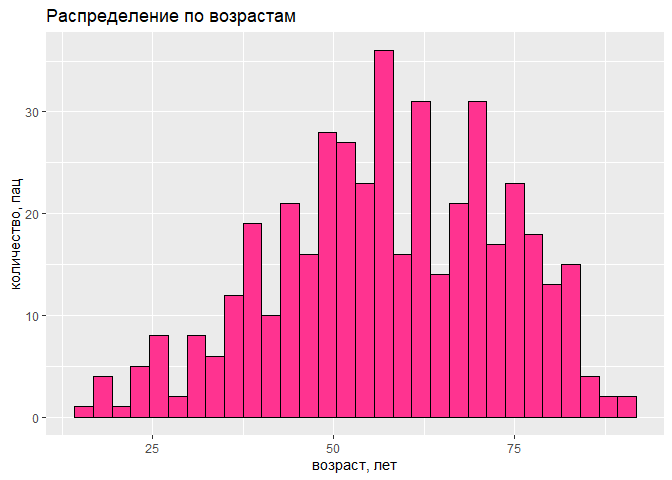

```r
patients%>%
  ggplot()+
  geom_histogram(aes(x=AGE),
                 color="black",
                 fill="#FF3390")+
  ggtitle("Распределение по возрастам")+
  labs(x="возраст, лет", y="количество, пац")
```

Вес пациентов

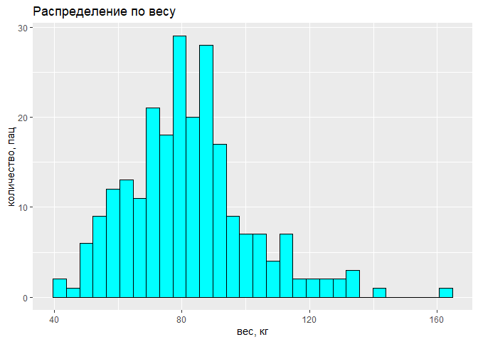

```r
patients%>%
  ggplot()+
  geom_histogram(aes(x=WEIGHT),
                 color="black",
                 fill="cyan")+
  ggtitle("Распределение по весу")+
  labs(x="вес, кг", y="количество, пац")
```

Пол пациентов:

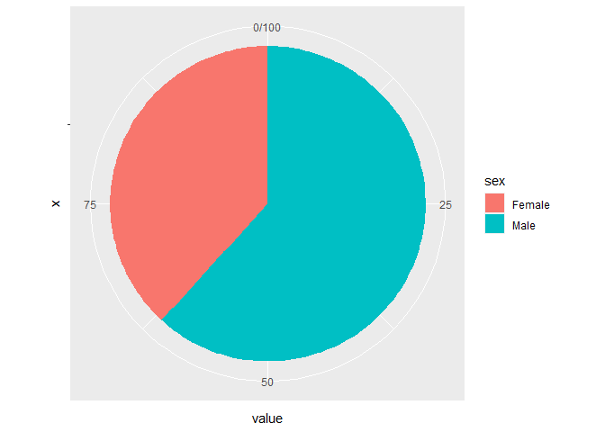

```r
N<-nrow(patients)

m <- patients %>%
  filter(SEX == 'Male')%>%
  nrow()/N*100

f <- patients %>%
  filter(SEX == 'Female')%>%
  nrow()/N*100

#na <- patients %>%
#  nrow()
#na <- na-m-f

df <- data.frame(
  sex = c("Male", "Female"),
  value = c(m, f)
  )

df %>%
  ggplot(
    aes(x="", y=value, fill=sex))+
  geom_bar(width = 1, stat = "identity")+
  coord_polar("y", start=0)
```

Степень злокачественности по AJCC

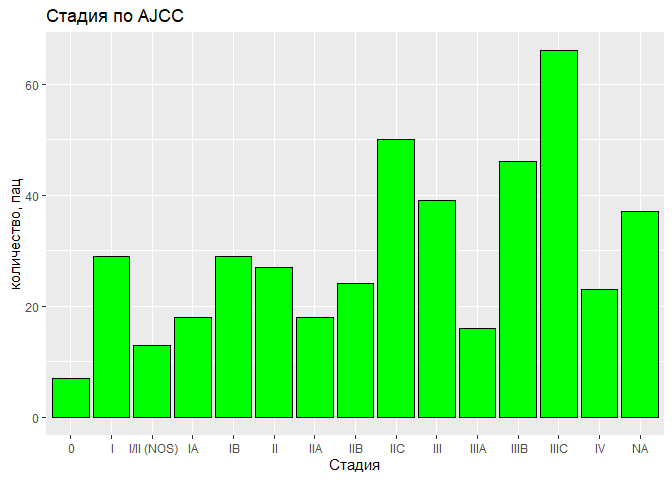

```r
patients$AJCC_PATHOLOGIC_TUMOR_STAGE<-gsub("STAGE","",as.character(patients$AJCC_PATHOLOGIC_TUMOR_STAGE))

patients%>%
  ggplot()+
  geom_bar(aes(x=AJCC_PATHOLOGIC_TUMOR_STAGE), position="dodge", fill = "green", color = "black")+
  ggtitle("Стадия по AJCC")+
  labs(x="Стадия", y="количество, пац")
```

##Образцы

Из файла: data_clinical_sample.txt

```r
samples <- read_tsv("data_clinical_sample.txt", skip = 4)
skimr::skim(samples)
```

Data summary

| Name | samples |
| --- | --- |
| Number of rows | 448 |
| Number of columns | 18 |
| _______________________ |  |
| Column type frequency: |  |
| character | 13 |
| logical | 1 |
| numeric | 4 |
| ________________________ |  |
| Group variables | None |

**Variable type: character**

| skim_variable | n_missing | complete_rate | min | max | empty | n_unique | whitespace |
| --- | --- | --- | --- | --- | --- | --- | --- |
| PATIENT_ID | 0 | 1 | 12 | 12 | 0 | 442 | 0 |
| SAMPLE_ID | 0 | 1 | 15 | 15 | 0 | 448 | 0 |
| ONCOTREE_CODE | 0 | 1 | 4 | 4 | 0 | 1 | 0 |
| CANCER_TYPE | 0 | 1 | 8 | 8 | 0 | 1 | 0 |
| CANCER_TYPE_DETAILED | 0 | 1 | 18 | 18 | 0 | 1 | 0 |
| TUMOR_TYPE | 0 | 1 | 23 | 23 | 0 | 1 | 0 |
| TISSUE_PROSPECTIVE_COLLECTION_INDICATOR | 0 | 1 | 2 | 3 | 0 | 2 | 0 |
| TISSUE_RETROSPECTIVE_COLLECTION_INDICATOR | 0 | 1 | 2 | 3 | 0 | 2 | 0 |
| TISSUE_SOURCE_SITE_CODE | 0 | 1 | 2 | 2 | 0 | 25 | 0 |
| TUMOR_TISSUE_SITE | 0 | 1 | 5 | 55 | 0 | 26 | 0 |
| SAMPLE_TYPE | 0 | 1 | 7 | 10 | 0 | 2 | 0 |
| SOMATIC_STATUS | 0 | 1 | 7 | 7 | 0 | 1 | 0 |
| TISSUE_SOURCE_SITE | 0 | 1 | 4 | 44 | 0 | 25 | 0 |

**Variable type: logical**

| skim_variable | n_missing | complete_rate | mean | count |
| --- | --- | --- | --- | --- |
| GRADE | 448 | 0 | NaN | : |

**Variable type: numeric**

| skim_variable | n_missing | complete_rate | mean | sd | p0 | p25 | p50 | p75 | p100 | hist |
| --- | --- | --- | --- | --- | --- | --- | --- | --- | --- | --- |
| ANEUPLOIDY_SCORE | 14 | 0.97 | 12.99 | 7.98 | 0.00 | 7.00 | 11.00 | 19.00 | 35.00 | ▆▇▅▃▁ |
| MSI_SCORE_MANTIS | 367 | 0.18 | 0.31 | 0.02 | 0.24 | 0.30 | 0.32 | 0.33 | 0.37 | ▁▂▇▇▁ |
| MSI_SENSOR_SCORE | 367 | 0.18 | 0.12 | 0.19 | 0.00 | 0.01 | 0.05 | 0.14 | 1.03 | ▇▂▁▁▁ |
| TMB_NONSYNONYMOUS | 8 | 0.98 | 25.91 | 55.65 | 0.20 | 7.04 | 14.88 | 31.39 | 1052.20 | ▇▁▁▁▁ |

*Всего образцов 448*

Описание файла:

- PATIENT_ID - айдентификатор пациента (TCGA-BF-A1PX)
- SAMPLE_ID - айлентификатор образца TCGA-BF-A1PX-01)
- ONCOTREE_CODE - Oncotree Code http://oncotree.mskcc.org/ (SKCM)
- CANCER_TYPE - тип рака (Melanoma)
- CANCER_TYPE_DETAILED- тип рака детальнее (Cutaneous Melanoma)
- TUMOR_TYPE - тип опухоли (Skin Cutaneous Melanoma)
- GRADE - Гистологическая степень новообразования (NA)
- TISSUE_PROSPECTIVE_COLLECTION_INDICATOR- Сбор тканей проспективный (Yes)
- TISSUE_RETROSPECTIVE_COLLECTION_INDICATOR-Сбор тканей ретроспективный(No)
- TISSUE_SOURCE_SITE_CODE-код откуда ткань (BF)
- TUMOR_TISSUE_SITE- Анатомическое место опухоли (Regional Lymph Node|Trunk)
- ANEUPLOIDY_SCORE - Оценка анеуплоидии (9)
- SAMPLE_TYPE - тип образца:i.e., normal, primary, met, recurrence (Metastasis)
- MSI_SCORE_MANTIS- Оценка MSI MANTIS (0.2612)
- MSI_SENSOR_SCORE- Оценка MSI, полученная с помощью датчика MSI (0.08)
- SOMATIC_STATUS - Соматический статус (Matched)
- TMB_NONSYNONYMOUS- Tumor Mutational Burden = Мутационная нагрузка опухоли несинонимичный (26.33333333) - * TMB, определяемый как количество соматических мутаций на мегабазу исследуемой геномной последовательности, варьируется в зависимости от злокачественных новообразований. https://www.ncbi.nlm.nih.gov/pmc/articles/PMC7710563/
- TISSUE_SOURCE_SITE- источник тканей образца: tissue, cell, or blood и клинические метаданные, которые затем отправляются на основной ресурс Biospecimen (Cureline)

Тип опухоли:

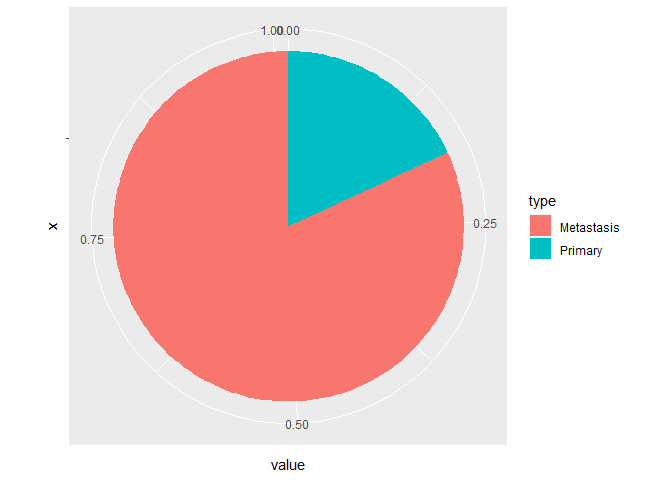

```r
p <- samples %>%
  filter(SAMPLE_TYPE == 'Primary')%>%
  nrow()/N

m <- samples %>%
  filter(SAMPLE_TYPE == 'Metastasis')%>%
  nrow()/N

#na <- samples %>%
#  nrow()
#na <- na-m-p

df <- data.frame(
  type = c("Primary", "Metastasis"),
  value = c(p, m)
  )

df %>%
  ggplot(
    aes(x="", y=value, fill=type))+
  geom_bar(width = 1, stat = "identity")+
  coord_polar("y", start=0)
```

*Итого:* 448 образцов от 442 пациентов (у 6 пациентов доступны образцы primary и metastasis, которые различаются по ANEUPLOIDY_SCORE, SAMPLE_TYPE, MSI_SCORE_MANTIS, MSI_SENSOR_SCORE, TMB_NONSYNONYMOUS)

```r
samples$PATIENT_ID[duplicated(samples$PATIENT_ID)]
```

```
## [1] "TCGA-D9-A1X3" "TCGA-D9-A4Z6" "TCGA-ER-A19T" "TCGA-ER-A2NF" "TCGA-HR-A2OG"
## [6] "TCGA-HR-A2OH"
```